# midterm project team 5

2022-10-16

install some packages or libraries

```r
library(ggplot2)
library(ezids)
library(dplyr)
library(readr)
```

# Data Shaping

## Read Data

Read the data .CSV files of adults arrest in DC area from 2016-2021

```r
df_2016<-data.frame(read.csv("Arrests 2016 Public.csv"))
df_2017<-data.frame(read.csv("Arrests 2017 Public.csv"))
df_2018<-data.frame(read.csv("Arrests by Year, 2018.csv"))
df_2019<-data.frame(read.csv("Arrests by Year, 2019.csv"))
df_2020<-data.frame(read.csv("Arrests by Year 2020.csv"))
df_2021<-data.frame(read.csv("2021 Adult Arrests.csv"))

c16 <- c(colnames(df_2016))
c18 <- c(colnames(df_2018))
```

Note that the colnames of df_2016 and df_2017 are not the same with others. We show the columns name of df_2016 and df_2018 in the below:

| col # | 2016 | 2018 |
| --- | --- | --- |
| 1 | Arrestee.Type | Arrestee.Type |
| 2 | Arrest.Year | Arrest.Year |
| 3 | Arrest.Date | Arrest.Date |
| 4 | Arrest.Hour | Arrest.Hour |
| 5 | CCN | CCN |
| 6 | Arrest.Number. | Arrest.Number. |
| 7 | Age | Age |
| 8 | Defendant.PSA | Defendant.PSA |
| 9 | Defendant.District | Defendant.District |
| 10 | Defendant.Race | Defendant.Race |
| 11 | Defendant.Ethnicity | Defendant.Ethnicity |
| 12 | Defendant.Sex | Defendant.Sex |
| 13 | Arrest.Category | Arrest.Category |
| 14 | Charge.Description | Charge.Description |
| 15 | Arrest.Location.PSA | Arrest.Location.PSA |
| 16 | Arrest.Location.District | Arrest.Location.District |
| 17 | Arrest.Location.Block.GeoX | Arrest.Block.GEOX |
| 18 | Arrest.Location.Block.GeoY | Arrest.Block.GEOY |
| 19 | Offense.GEOY | Arrest.Latitude |
| 20 | Offense.GEOX | Arrest.Longitude |
| 21 | Offense.PSA | Offense.Location.PSA |
| 22 | Offense.District | Offense.Location.District |
| 23 | Arrest.Latitude | Offense.Block.GEOX |
| 24 | Arrest.Longitude | Offense.Block.GEOY |
| 25 | Offense.Latitude | Offense.Latitude |
| 26 | Offense.Longitude | Offense.Longitude |

## Merge Multiple CSV Files

You can see that the columns name are same from the first column to the 14th column in both data. On the other hand, the name and order of 15th and latter columns are a bit different in those data. The latter columns are about locations, and we are not very interested in the detail location. Therefore, we will delete the latter columns except for the 16th and 22nd columns. In addition, we will drop `CNN` (col #5) and `Arrest.Number.` (col #6) because they are IDs and useless for our analysis.

After deleting some columns, we will bind data frames by rows.

```r
#bind df_2016 and df_2017, and delete some columns
df_16_17 <- rbind(df_2016, df_2017)[,-c(5,6,15,17:21,23:26)]
names(df_16_17)[c(13,14)] <- c('Arrest.Location.District','Offense.Location.District')   #rename columns

#bind df_2018 - df_2021, and delete some columns
df_18_21 <- rbind(df_2018, df_2019, df_2020, df_2021)[,-c(5,6,15,17:21,23:26)]

DF<-rbind(df_16_17,df_18_21)
colnames(DF)
```

```
##  [1] "Arrestee.Type"             "Arrest.Year"
##  [3] "Arrest.Date"               "Arrest.Hour"
##  [5] "Age"                       "Defendant.PSA"
##  [7] "Defendant.District"        "Defendant.Race"
##  [9] "Defendant.Ethnicity"       "Defendant.Sex"
## [11] "Arrest.Category"           "Charge.Description"
## [13] "Arrest.Location.District"  "Offense.Location.District"
```

```r
str(DF)
```

```
## 'data.frame':    152386 obs. of  14 variables:
##  $ Arrestee.Type            : chr  "Adult Arrest" "Adult Arrest" "Adult Arrest" "Adult Arrest" ...
##  $ Arrest.Year              : int  2016 2016 2016 2016 2016 2016 2016 2016 2016 2016 ...
##  $ Arrest.Date              : chr  "2016-01-01" "2016-01-01" "2016-01-01" "2016-01-01" ...
##  $ Arrest.Hour              : int  0 0 0 0 0 0 1 1 1 1 ...
##  $ Age                      : int  39 27 21 52 33 22 26 27 23 34 ...
##  $ Defendant.PSA            : chr  "Out of State" "Out of State" "Out of State" "603" ...
##  $ Defendant.District       : chr  "Out of State" "Out of State" "Out of State" "6D" ...
##  $ Defendant.Race           : chr  "WHITE" "WHITE" "BLACK" "BLACK" ...
##  $ Defendant.Ethnicity      : chr  "UNKNOWN" "NOT HISPANIC" "NOT HISPANIC" "NOT HISPANIC" ...
##  $ Defendant.Sex            : chr  "MALE" "MALE" "MALE" "MALE" ...
##  $ Arrest.Category          : chr  "Simple Assault" "Simple Assault" "Assault on a Police Officer" "Traffic Violations" ...
##  $ Charge.Description       : chr  "Threats To Do Bodily Harm -misd" "Simple Assault" "Assault On A Police Officer (simple Assault)" "Permit Suspended-oas" ...
##  $ Arrest.Location.District : chr  "2D" "3D" "3D" "6D" ...
##  $ Offense.Location.District: chr  "2D" "3D" "3D" "6D" ...
```

```r
xkablesummary(DF)
```

Table: Statistics summary.

|  | Arrestee.Type | Arrest.Year | Arrest.Date | Arrest.Hour | Age | Defendant.PSA | Defendant.District | Defendant.Race | Defendant.Ethnicity | Defendant.Sex | Arrest.Category | Charge.Description | Arrest.Location.District | Offense.Location.District |
| --- | --- | --- | --- | --- | --- | --- | --- | --- | --- | --- | --- | --- | --- | --- |
| Min | Length:152386 | Min. :2016 | Length:152386 | Min. : 0.00 | Min. : 18.00 | Length:152386 | Length:152386 | Length:152386 | Length:152386 | Length:152386 | Length:152386 | Length:152386 | Length:152386 | Length:152386 |
| Q1 | Class :character | 1st Qu.:2017 | Class :character | 1st Qu.: 6.00 | 1st Qu.: 25.00 | Class :character | Class :character | Class :character | Class :character | Class :character | Class :character | Class :character | Class :character | Class :character |
| Median | Mode :character | Median :2018 | Mode :character | Median :12.00 | Median : 32.00 | Mode :character | Mode :character | Mode :character | Mode :character | Mode :character | Mode :character | Mode :character | Mode :character | Mode :character |
| Mean | NA | Mean :2018 | NA | Mean :11.81 | Mean : 35.19 | NA | NA | NA | NA | NA | NA | NA | NA | NA |
| Q3 | NA | 3rd Qu.:2019 | NA | 3rd Qu.:18.00 | 3rd Qu.: 43.00 | NA | NA | NA | NA | NA | NA | NA | NA | NA |
| Max | NA | Max. :2021 | NA | Max. :23.00 | Max. :121.00 | NA | NA | NA | NA | NA | NA | NA | NA | NA |

## Drop some rows

Since we are interested in crimes committed by while males, we will drop rows where the value of `Defendant.Race` is not “White”.

In addition, `Arrest.Category` has some different values for 2021 and other years:

- Data in 2021 has “Release Violations/Fugitive (Fug)” and “Release Violations/Fugitive (Warr)” although data in other years have “Release Violations/Fugitive” instead of them.
- Data in 2021 has “Fraud and Financial Crimes (Frau)” although data in other years have “Fraud and Financial Crimes”.

Therefore, we wil covert these values in 2021 into the correspond values in other years.

```r
DF_WM <- subset(DF, subset = Defendant.Race=='WHITE' & Defendant.Sex=='MALE')
DF_WM <- mutate(DF_WM, Arrest.Category = gsub(Arrest.Category, pattern = "Release Violations/Fugitive.*", replacement = "Release Violations/Fugitive"))
DF_WM <- mutate(DF_WM, Arrest.Category = gsub(Arrest.Category, pattern = "Fraud and Financial Crimes.*", replacement = "Fraud and Financial Crimes"))
str(DF_WM)
```

```
## 'data.frame':    12283 obs. of  14 variables:
##  $ Arrestee.Type            : chr  "Adult Arrest" "Adult Arrest" "Adult Arrest" "Adult Arrest" ...
##  $ Arrest.Year              : int  2016 2016 2016 2016 2016 2016 2016 2016 2016 2016 ...
##  $ Arrest.Date              : chr  "2016-01-01" "2016-01-01" "2016-01-01" "2016-01-01" ...
##  $ Arrest.Hour              : int  0 0 1 1 13 2 3 3 6 7 ...
##  $ Age                      : int  39 27 27 26 48 25 21 41 29 22 ...
##  $ Defendant.PSA            : chr  "Out of State" "Out of State" "Out of State" "Out of State" ...
##  $ Defendant.District       : chr  "Out of State" "Out of State" "Out of State" "Out of State" ...
##  $ Defendant.Race           : chr  "WHITE" "WHITE" "WHITE" "WHITE" ...
##  $ Defendant.Ethnicity      : chr  "UNKNOWN" "NOT HISPANIC" "HISPANIC" "NOT HISPANIC" ...
##  $ Defendant.Sex            : chr  "MALE" "MALE" "MALE" "MALE" ...
##  $ Arrest.Category          : chr  "Simple Assault" "Simple Assault" "Driving/Boating While Intoxicated" "Simple Assault" ...
##  $ Charge.Description       : chr  "Threats To Do Bodily Harm -misd" "Simple Assault" "Driving While Intoxicated -2nd Off" "Simple Assault" ...
##  $ Arrest.Location.District : chr  "2D" "3D" "4D" "5D" ...
##  $ Offense.Location.District: chr  "2D" "3D" "4D" "5D" ...
```

```r
xkablesummary(DF_WM)
```

Table: Statistics summary.

|  | Arrestee.Type | Arrest.Year | Arrest.Date | Arrest.Hour | Age | Defendant.PSA | Defendant.District | Defendant.Race | Defendant.Ethnicity | Defendant.Sex | Arrest.Category | Charge.Description | Arrest.Location.District | Offense.Location.District |
| --- | --- | --- | --- | --- | --- | --- | --- | --- | --- | --- | --- | --- | --- | --- |
| Min | Length:12283 | Min. :2016 | Length:12283 | Min. : 0.00 | Min. : 18.00 | Length:12283 | Length:12283 | Length:12283 | Length:12283 | Length:12283 | Length:12283 | Length:12283 | Length:12283 | Length:12283 |
| Q1 | Class :character | 1st Qu.:2017 | Class :character | 1st Qu.: 4.00 | 1st Qu.: 25.00 | Class :character | Class :character | Class :character | Class :character | Class :character | Class :character | Class :character | Class :character | Class :character |
| Median | Mode :character | Median :2018 | Mode :character | Median :11.00 | Median : 32.00 | Mode :character | Mode :character | Mode :character | Mode :character | Mode :character | Mode :character | Mode :character | Mode :character | Mode :character |
| Mean | NA | Mean :2018 | NA | Mean :11.17 | Mean : 34.58 | NA | NA | NA | NA | NA | NA | NA | NA | NA |
| Q3 | NA | 3rd Qu.:2019 | NA | 3rd Qu.:18.00 | 3rd Qu.: 42.00 | NA | NA | NA | NA | NA | NA | NA | NA | NA |
| Max | NA | Max. :2021 | NA | Max. :23.00 | Max. :121.00 | NA | NA | NA | NA | NA | NA | NA | NA | NA |

# EDA

The number of crimes is as follows.

| year | the number of crimes |
| --- | --- |
| 2016 | 2620 |
| 2017 | 2636 |
| 2018 | 2298 |
| 2019 | 2193 |
| 2020 | 1426 |
| 2021 | 1110 |
| 2016 - 2019 (before COVID-19) | 2437 |
| 2020 - 2021 (after COVID-19) | 1268 |

## Including Plots

We will create some bar plots to see the number of occurrences per type of crime.  
The Bar plot of crimes in 2016 - 2021 is as follows:

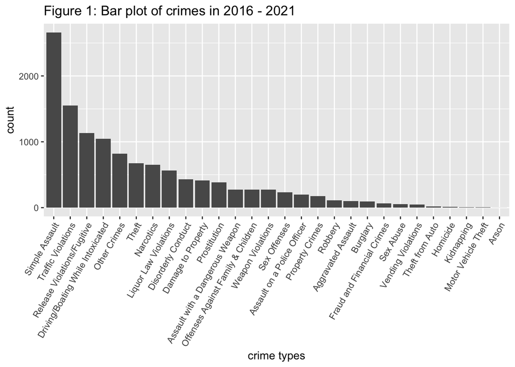

```r
ggplot(DF_WM, aes(forcats::fct_infreq(Arrest.Category))) +
  ggtitle("Figure 1: Bar plot of crimes in 2016 - 2021") + xlab("crime types") + geom_bar() +
  theme(axis.text.x = element_text(angle = 60, hjust = 1))
```

The Bar plots of crimes before COVID-19 (2016 - 2019) and after COVID-19 (2020 - 2021) are as follows:

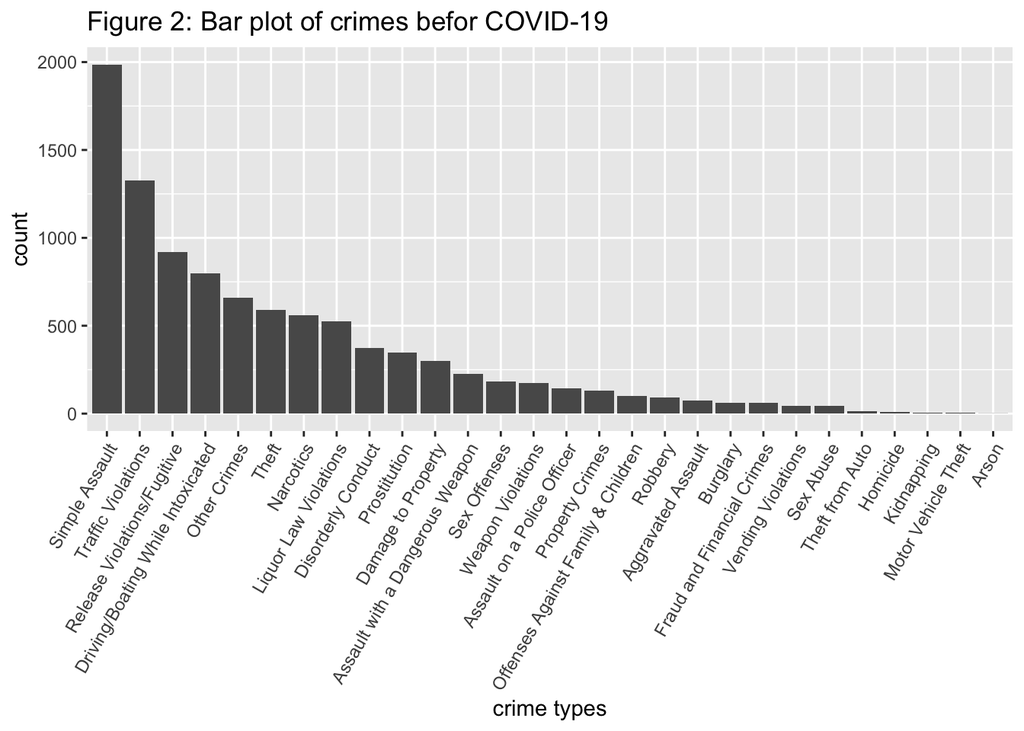

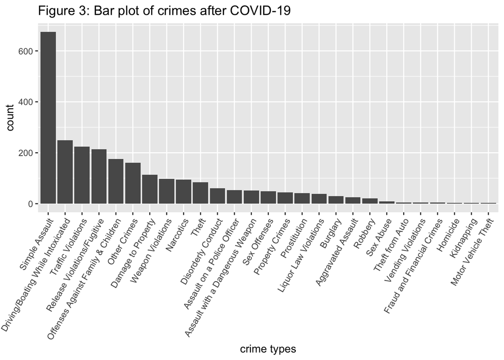

```r
ggplot(subset(DF_WM,Arrest.Year <= 2019), aes(forcats::fct_infreq(Arrest.Category))) +
  ggtitle("Figure 2: Bar plot of crimes befor COVID-19") + xlab("crime types") + geom_bar() +
  theme(axis.text.x = element_text(angle = 60, hjust = 1))

ggplot(subset(DF_WM,Arrest.Year > 2019), aes(forcats::fct_infreq(Arrest.Category))) +
  ggtitle("Figure 3: Bar plot of crimes after COVID-19") + xlab("crime types") + geom_bar() +
  theme(axis.text.x = element_text(angle = 60, hjust = 1))
```

The Bar plots of crimes in each year are as follows:

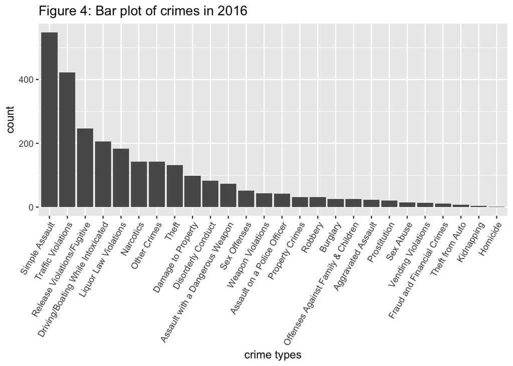

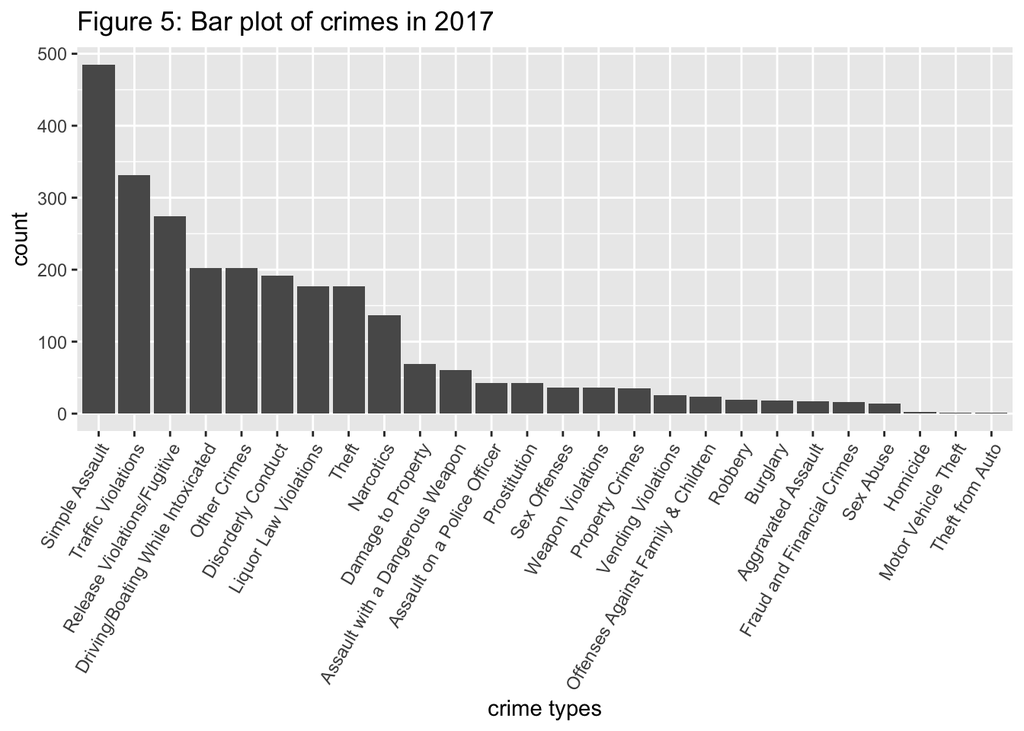

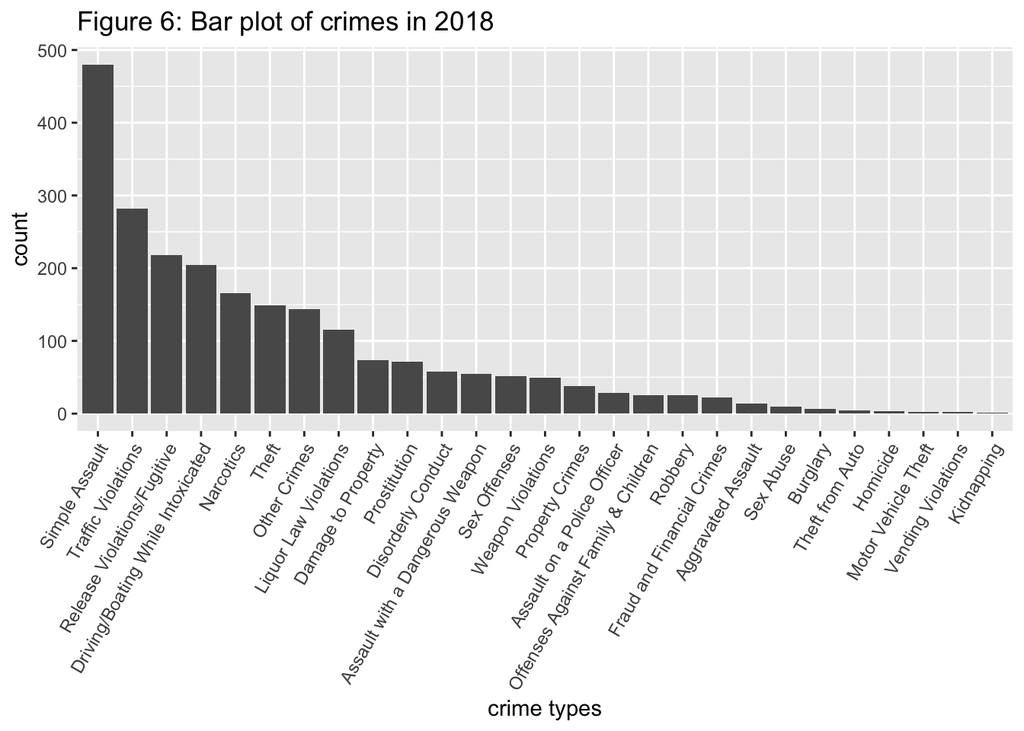

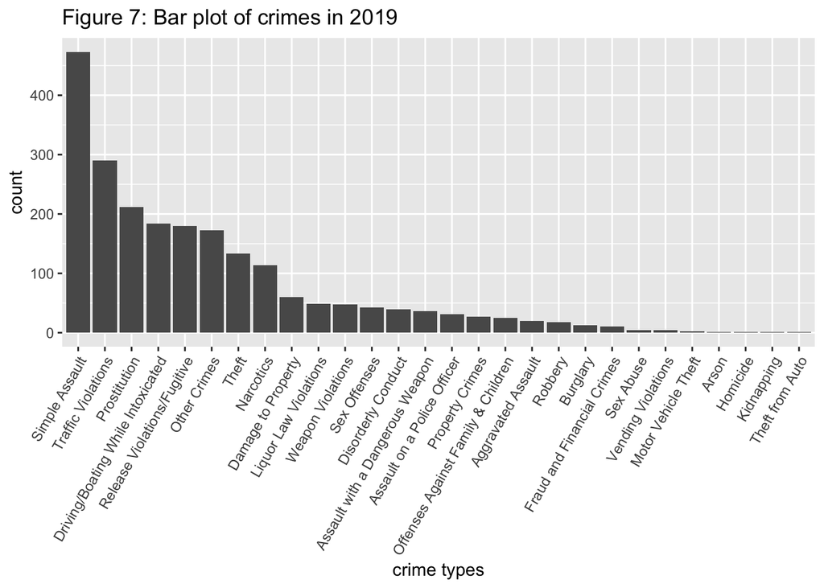

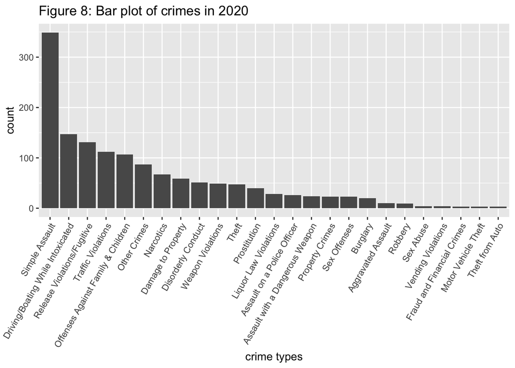

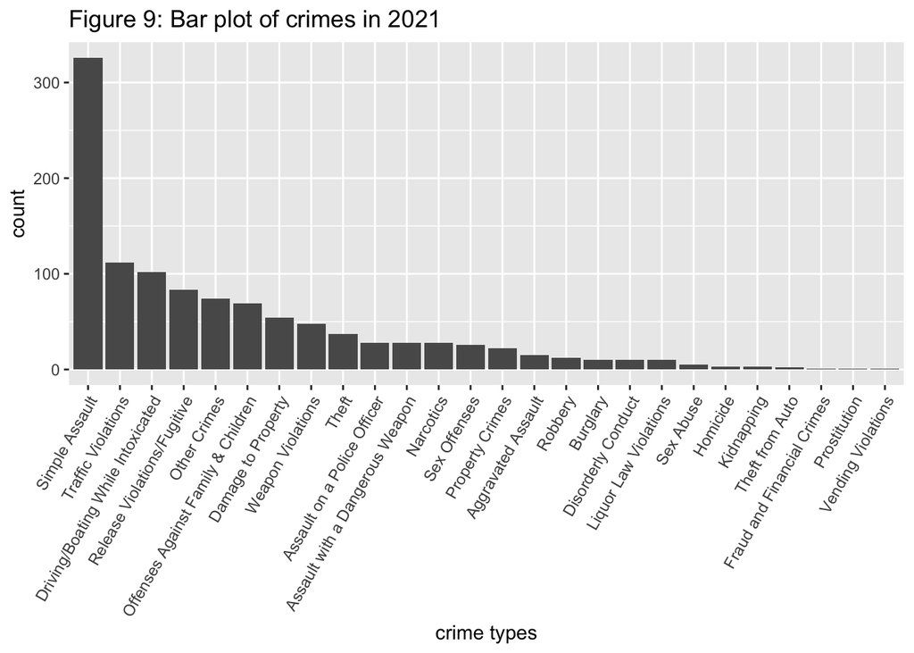

```r
ggplot(subset(DF_WM,Arrest.Year == 2016), aes(forcats::fct_infreq(Arrest.Category))) +
  ggtitle("Figure 4: Bar plot of crimes in 2016") + xlab("crime types") + geom_bar() +
  theme(axis.text.x = element_text(angle = 60, hjust = 1))

ggplot(subset(DF_WM,Arrest.Year == 2017), aes(forcats::fct_infreq(Arrest.Category))) +
  ggtitle("Figure 5: Bar plot of crimes in 2017") + xlab("crime types") + geom_bar() +
  theme(axis.text.x = element_text(angle = 60, hjust = 1))

ggplot(subset(DF_WM,Arrest.Year == 2018), aes(forcats::fct_infreq(Arrest.Category))) +
  ggtitle("Figure 6: Bar plot of crimes in 2018") + xlab("crime types") + geom_bar() +
  theme(axis.text.x = element_text(angle = 60, hjust = 1))

ggplot(subset(DF_WM,Arrest.Year == 2019), aes(forcats::fct_infreq(Arrest.Category))) +
  ggtitle("Figure 7: Bar plot of crimes in 2019") + xlab("crime types") + geom_bar() +
  theme(axis.text.x = element_text(angle = 60, hjust = 1))

ggplot(subset(DF_WM,Arrest.Year == 2020), aes(forcats::fct_infreq(Arrest.Category))) +
  ggtitle("Figure 8: Bar plot of crimes in 2020") + xlab("crime types") + geom_bar() +
  theme(axis.text.x = element_text(angle = 60, hjust = 1))

ggplot(subset(DF_WM,Arrest.Year == 2021), aes(forcats::fct_infreq(Arrest.Category))) +
  ggtitle("Figure 9: Bar plot of crimes in 2021") + xlab("crime types") + geom_bar() +
  theme(axis.text.x = element_text(angle = 60, hjust = 1))
```

In order to check changes in crime trends, the graph below illustrates, for each crime type, the change over time in the percentage of crimes of that crime type in all crimes.

```r
#  table of the number of each crime type in each year
table_freq <- xtabs(~Arrest.Year+Arrest.Category,DF_WM)

# total number of crimes in each year
sum16 <- sum(table_freq[1,])
sum17 <- sum(table_freq[2,])
sum18 <- sum(table_freq[3,])
sum19 <- sum(table_freq[4,])
sum20 <- sum(table_freq[5,])
sum21 <- sum(table_freq[6,])
sum_lst <- c(sum16,sum17,sum18,sum19,sum20,sum21)

# table of the percentage of crimes in each year
table_rfreq <- table_freq/sum_lst

# convert table_rfreq into dataframe
DF_rfreq <- data.frame(table_rfreq)

# convert the data type of 'Arrest.Year' from factor into numeric
DF_rfreq$Arrest.Year <- as.character(DF_rfreq$Arrest.Year) %>% as.numeric()
```

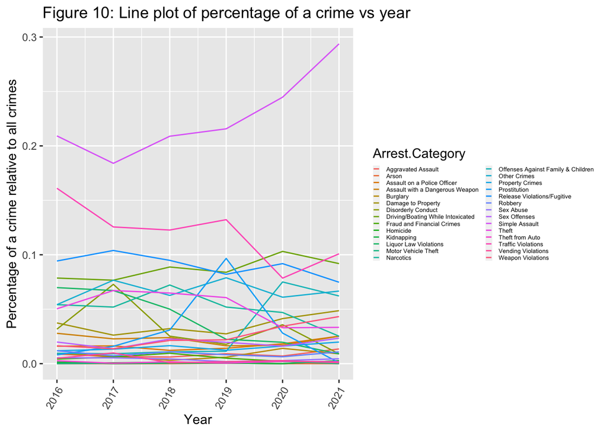

```r
#install.packages("ggrepel")
library(ggrepel)

ggplot(DF_rfreq, aes(x=Arrest.Year, y=Freq, color=Arrest.Category, group=Arrest.Category)) +
  ggtitle("Figure 10: Line plot of percentage of a crime vs year") + xlab("Year") +
  ylab("Percentage of a crime relative to all crimes") +
  geom_line() +
  theme(axis.text.x = element_text(angle = 60, hjust = 1),
        legend.text = element_text(size=5),
        legend.key.size = unit(0.2, 'cm')) #+
```

```r
  #scale_y_log10() +
  #geom_text_repel(
   # data = subset(DF_rfreq, Arrest.Year == 2021),
   # aes(label = Arrest.Category),
    #max.overlaps = Inf,
    #nudge_x = 3,
    #segment.alpha = 0.3,
    #size = 2
  #) +
  #lims(x = c(2016, 2024))
```

```r
tmp <- DF_rfreq[DF_rfreq$Arrest.Year==2021,]
tmp <- tmp$Arrest.Category[order(-tmp$Freq)]
tmp <- as.character(tmp)
```

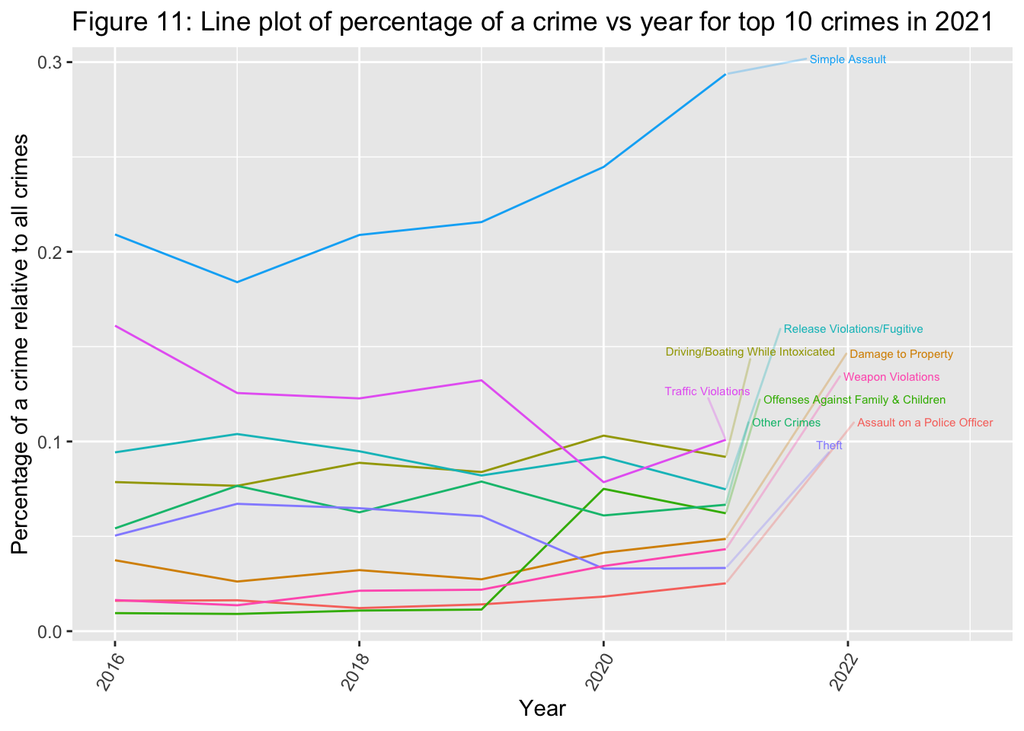

```r
DF_rfreq_10 <- subset(DF_rfreq, Arrest.Category %in% tmp[c(1:10)])

ggplot(DF_rfreq_10, aes(x=Arrest.Year, y=Freq, color=Arrest.Category, group=Arrest.Category)) +
  ggtitle("Figure 11: Line plot of percentage of a crime vs year for top 10 crimes in 2021") + xlab("Year") +
  ylab("Percentage of a crime relative to all crimes") +
  geom_line() +
  theme(axis.text.x = element_text(angle = 60, hjust = 1), legend.position = "none") +
  #scale_y_log10() +
  geom_text_repel(
    data = subset(DF_rfreq_10, Arrest.Year == 2021),
    aes(label = Arrest.Category),
    #max.overlaps = Inf,
    nudge_x = 1,
    nudge_y = 0.08,
    segment.alpha = 0.3,
    size = 2
  ) +
  lims(x = c(2016, 2023))
```

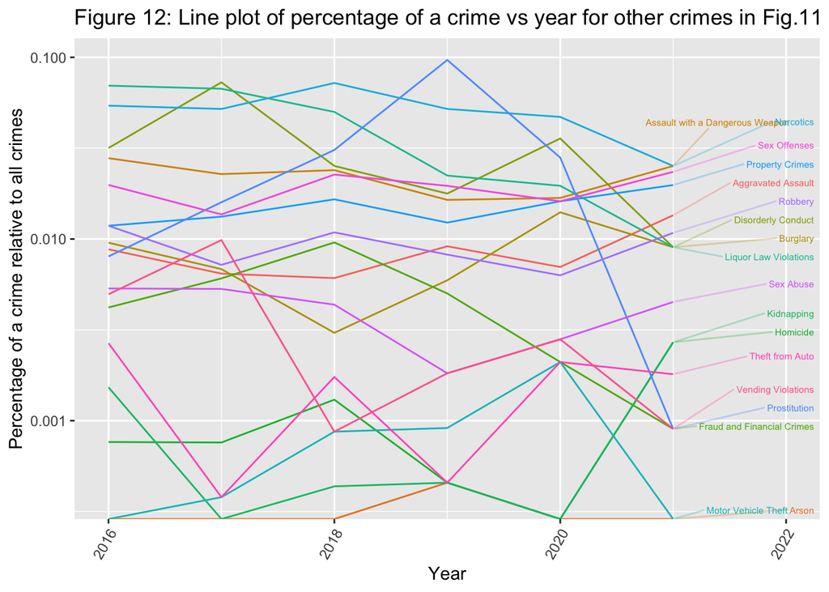

```r
DF_rfreq_non10 <- subset(DF_rfreq, Arrest.Category %in% tmp[-c(1:10)])

ggplot(DF_rfreq_non10, aes(x=Arrest.Year, y=Freq, color=Arrest.Category, group=Arrest.Category)) +
  ggtitle("Figure 12: Line plot of percentage of a crime vs year for other crimes in Fig.11") + xlab("Year") +
  ylab("Percentage of a crime relative to all crimes") +
  geom_line() +
  theme(axis.text.x = element_text(angle = 60, hjust = 1), legend.position = "none") +
  scale_y_log10() +
  geom_text_repel(
    data = subset(DF_rfreq_non10, Arrest.Year == 2021),
    aes(label = Arrest.Category),
    #max.overlaps = Inf,
    nudge_x = 30,
    nudge_y = 0.1,
    segment.alpha = 0.3,
    size = 2
  ) +
  lims(x = c(2016, 2022))
```

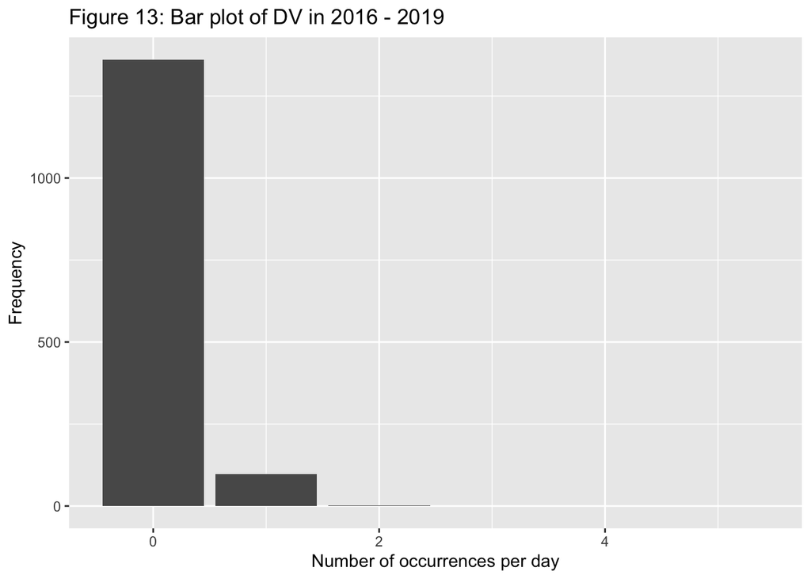

```r
DF_WM_16_19 <- DF_WM[DF_WM$Arrest.Year%in%c(2016,2017,2018,2019),]
DF_WM_16_19_DV <- DF_WM_16_19[DF_WM_16_19$Arrest.Category=='Offenses Against Family & Children',]

x_DV <- c(0,1,2,3,4,5)
y_DV <- c(365*4-99,98,1,0,0,0)
data_DV <- data.frame(x_DV, y_DV)

ggplot(data_DV, aes(x=x_DV,y=y_DV)) +
  ggtitle("Figure 13: Bar plot of DV in 2016 - 2019") +
  xlab("Number of occurrences per day") +
  ylab("Frequency") +
  geom_bar(stat = "identity")
```

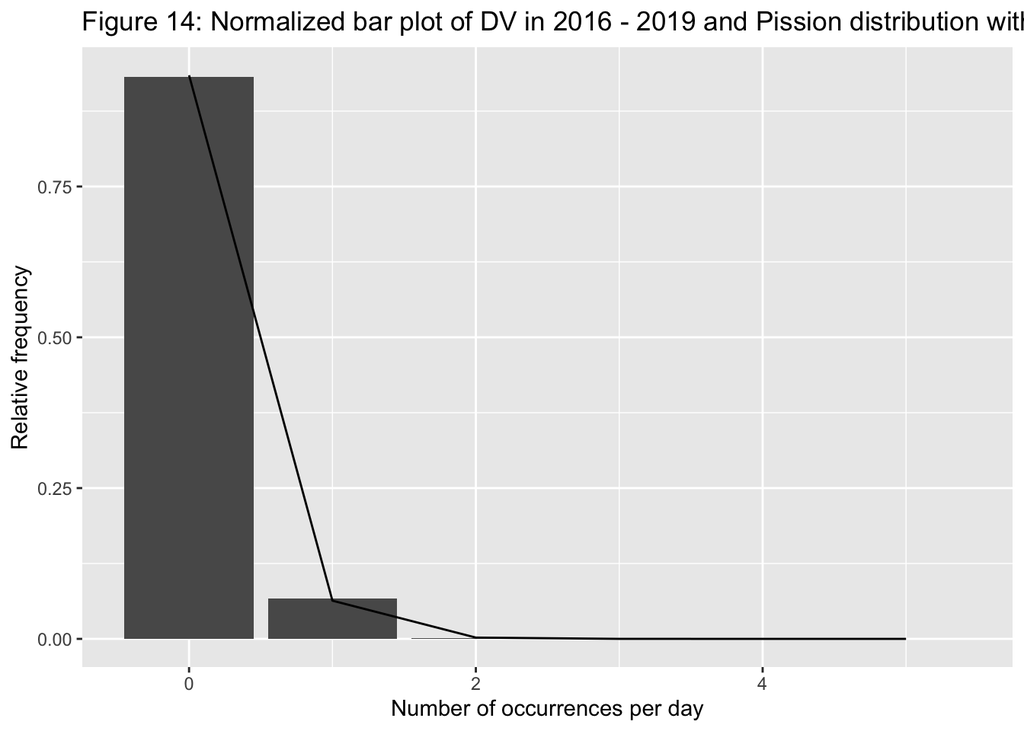

```r
x <- 0:5
fx <- dpois(x=x, lambda=99/(365*4))

data_DV <- data.frame(x_DV, y_DV, fx)
ggplot(data_DV) +
  ggtitle("Figure 14: Normalized bar plot of DV in 2016 - 2019 and Pission distribution with gamma = 0.0678") +
  xlab("Number of occurrences per day") +
  ylab("Relative frequency") +
  geom_bar(aes(x=x_DV,y=y_DV/(365*4)), stat = "identity") +
  geom_line(aes(x=x_DV,y=fx))
```